# Omics integraive pipeline: STATegRa

#### 2.1.4.3 Methylation data (`logit_met_skcm`)

As methylation data no follows a gausian distribution, a non-parametric ComBat is applied.

```r
logit_met_skcm_corrected <- ComBat(logit_met_skcm_corrected,
                                  batch=batch,
                                  mod=mod,
                                  prior.plot=TRUE,
                                  par.prior=FALSE,
                                  BPPARAM=MulticoreParam())
```

Note: the non-parametric ComBat spends long time (>4days) to compute the corrected matrix.

Exploring the PCA from corrected data we can see that the batch effect have been removed.

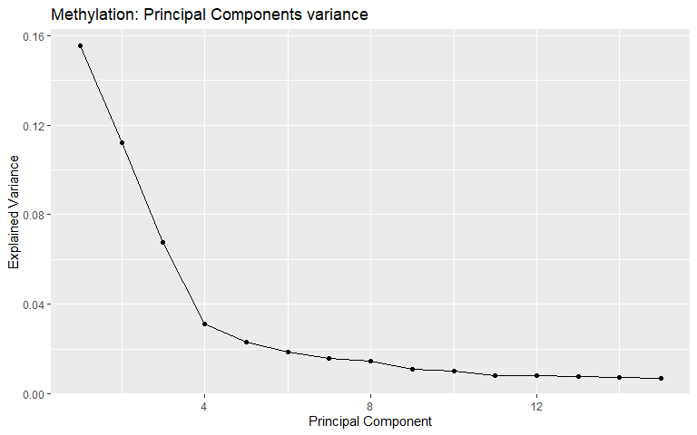

```r
pca_met <- prcomp(t(logit_met_skcm_corrected))
var_prcomp <- pca_met$sdev^2

# Plot PCs variance
pcvar <- data.frame(var=var_prcomp/sum(var_prcomp), pc=c(1:length(var_prcomp)))
ggplot(pcvar[1:15,], aes(x = pc)) + geom_line(aes(y=var)) +
  labs(x='Principal Component', y='Explained Variance') +
  geom_point(aes(y=var)) +
  ggtitle('Methylation: Principal Components variance')
```

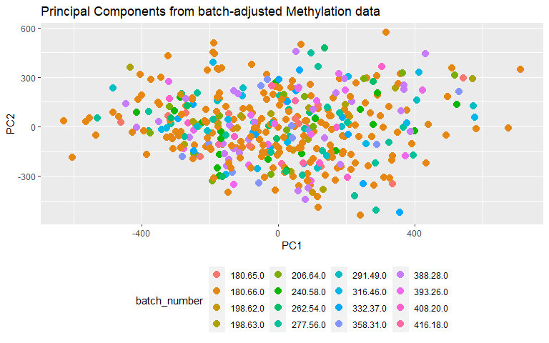

```r
# Plot PCs scores
df <- data.frame(PC1=pca_met$x[,1], PC2=pca_met$x[,2],
                 batch_number=clinical_skcm$batch_number)

ggplot(df) +
  geom_point(aes(x=PC1, y=PC2, color=factor(batch_number)), size=5, shape=20) +
  guides(color=guide_legend("batch_number"),fill=guide_legend("batch_number")) +
  ggtitle("Principal Components from batch-adjusted Methylation data") +
  theme(legend.position="bottom")
```

Now, the association analysis shows how the batch effect is clearly removed from our data.

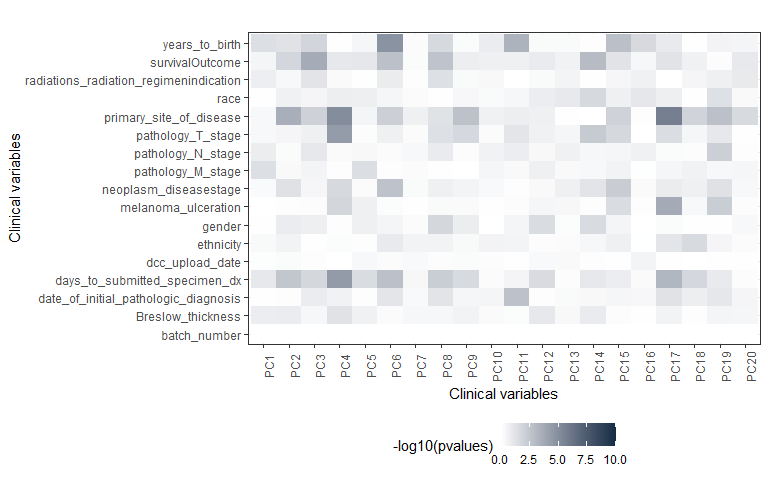

```r
pcaCorrelation(clinical=clinical_skcm[colnames(logit_met_skcm_corrected),],
               clin_var=clin_var, pca_data=pca_met$x, maxlogPvalue = 10)
```

## 2.2 Characterization of the data: Individual exploration.

After data pre-proces (filter, normalization and batch correction) the exploration of target cases should be done. First of all we will generate the data matrices with the data of study. We will work with just the 104 samples with curated metadata identified before.

```r
subset_log2_rna_skcm_corrected <- log2_rna_skcm_corrected[,rownames(clinical_skcm2)]
subset_log2_mirna_skcm_corrected <- log2_mirna_skcm_corrected[,rownames(clinical_skcm2)]
subset_logit_met_skcm_corrected <- logit_met_skcm_corrected[,rownames(clinical_skcm2)]
```

Let’s see the dimension of the final data:

```r
dim(subset_log2_rna_skcm_corrected)
```

```
## [1] 20225   104
```

```r
dim(subset_log2_mirna_skcm_corrected)
```

```
## [1] 898 104
```

```r
dim(subset_logit_met_skcm_corrected)
```

```
## [1] 305180    104
```

### 2.2.1 Expression data (`subset_log2_rna_skcm_corrected`)

Exploring the PCA from mRNA data (20,225 x 104)

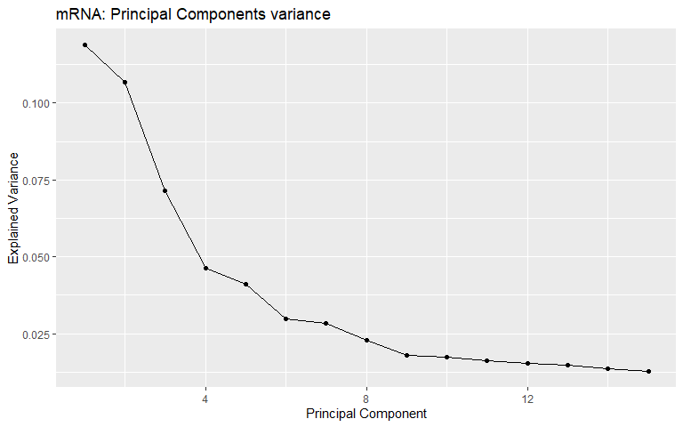

```r
pca_rna <- prcomp(t(subset_log2_rna_skcm_corrected))
var_prcomp <- pca_rna$sdev^2

# Plot PCs variance
pcvar <- data.frame(var=var_prcomp/sum(var_prcomp), pc=c(1:length(var_prcomp)))
ggplot(pcvar[1:15,], aes(x = pc)) + geom_line(aes(y=var)) +
  labs(x='Principal Component', y='Explained Variance') +
  geom_point(aes(y=var)) +
  ggtitle('mRNA: Principal Components variance')
```

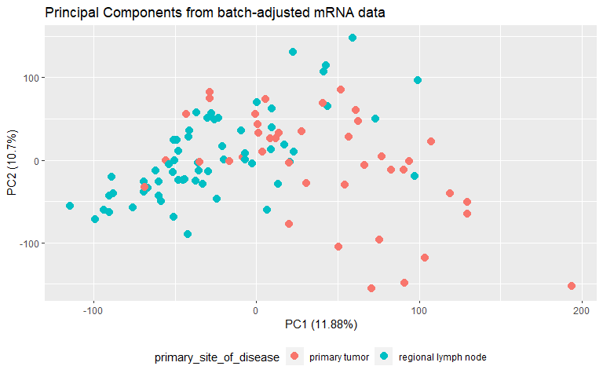

```r
# Plot PCs scores
df <- data.frame(PC1=pca_rna$x[,1], PC2=pca_rna$x[,2],
                 primary_site_of_disease=clinical_skcm2$primary_site_of_disease)

ggplot(df) +
  geom_point(aes(x=PC1, y=PC2, color=factor(primary_site_of_disease)), size=5, shape=20) +
  guides(color=guide_legend("primary_site_of_disease"),fill=guide_legend("primary_site_of_disease")) +
  labs(x='PC1 (11.88%)', y='PC2 (10.7%)') +
  ggtitle("Principal Components from batch-adjusted mRNA data") +
  theme(legend.position="bottom")
```

The main variables explaining the highest variability are “primary site of disease” and “neoplasm disease stage”.

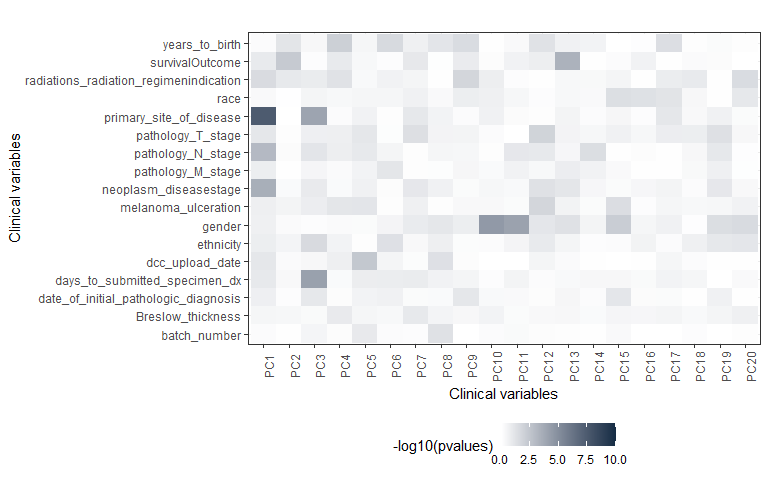

```r
pcaCorrelation(clinical=clinical_skcm2[colnames(subset_log2_rna_skcm_corrected),],
               clin_var=clin_var, pca_data=pca_rna$x, maxlogPvalue=10)
```

### 2.2.2 miRNA data (`subset_log2_mirna_skcm_corrected`)

Exploring the PCA from miRNA data (898 x 104)

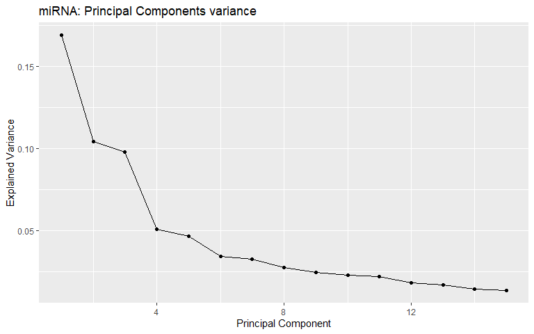

```r
pca_mirna <- prcomp(t(subset_log2_mirna_skcm_corrected))
var_prcomp <- pca_mirna$sdev^2

# Plot PCs variance
pcvar <- data.frame(var=var_prcomp/sum(var_prcomp), pc=c(1:length(var_prcomp)))
ggplot(pcvar[1:15,], aes(x = pc)) + geom_line(aes(y=var)) +
  labs(x='Principal Component', y='Explained Variance') +
  geom_point(aes(y=var)) +
  ggtitle('miRNA: Principal Components variance')
```

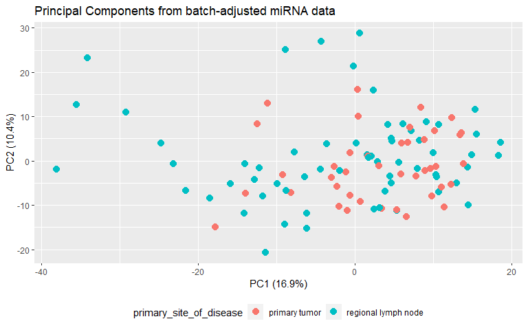

```r
# Plot PCs scores
df <- data.frame(PC1=pca_mirna$x[,1], PC2=pca_mirna$x[,2], PC3=pca_mirna$x[,3],
                 primary_site_of_disease=clinical_skcm2$primary_site_of_disease)

ggplot(df) +
  geom_point(aes(x=PC1, y=PC2, color=factor(primary_site_of_disease)), size=5, shape=20) +
  guides(color=guide_legend("primary_site_of_disease"),fill=guide_legend("primary_site_of_disease")) +
  labs(x='PC1 (16.9%)', y='PC2 (10.4%)') +
  ggtitle("Principal Components from batch-adjusted miRNA data") +
  theme(legend.position="bottom")
```

Again, “primary site of disease” appears as one of the most relevant variables to explain most of the data variablity.

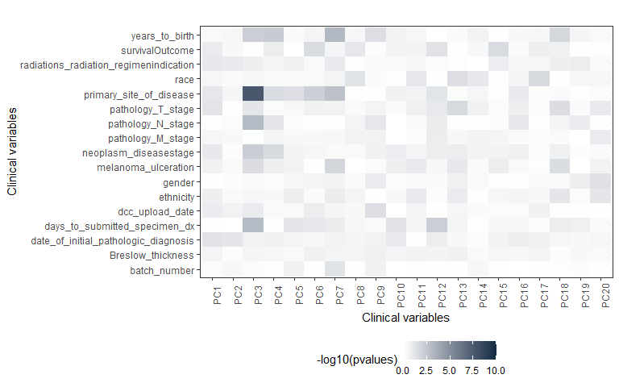

```r
pcaCorrelation(clinical=clinical_skcm2[colnames(subset_log2_mirna_skcm_corrected),],
               clin_var=clin_var, pca_data=pca_mirna$x, maxlogPvalue=10)
```

### 2.2.3 Methylation data (`subset_logit_met_skcm_corrected`)

Exploring the PCA from Methylation data (305,180 x 104)

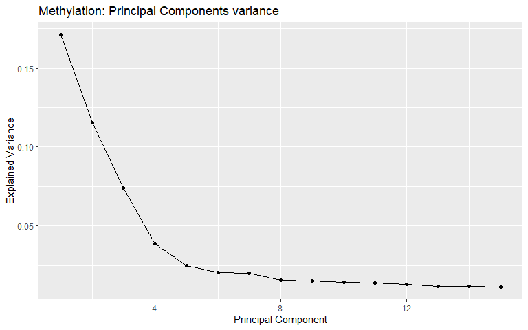

```r
pca_met <- prcomp(t(subset_logit_met_skcm_corrected))
var_prcomp <- pca_met$sdev^2

# Plot PCs variance
pcvar <- data.frame(var=var_prcomp/sum(var_prcomp), pc=c(1:length(var_prcomp)))
ggplot(pcvar[1:15,], aes(x = pc)) + geom_line(aes(y=var)) +
  labs(x='Principal Component', y='Explained Variance') +
  geom_point(aes(y=var)) +
  ggtitle('Methylation: Principal Components variance')
```

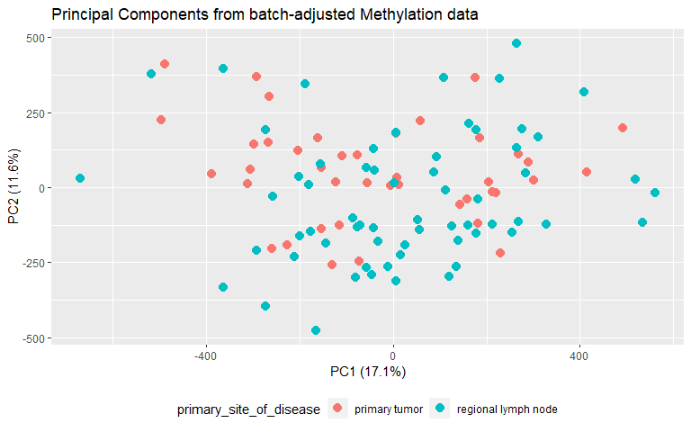

```r
# Plot PCs scores
df <- data.frame(PC1=pca_met$x[,1], PC2=pca_met$x[,2], PC3=pca_met$x[,3],
                 primary_site_of_disease=clinical_skcm2$primary_site_of_disease,
                 ulceration=clinical_skcm2$melanoma_ulceration)

ggplot(df) +
  geom_point(aes(x=PC1, y=PC2, color=factor(primary_site_of_disease)), size=5, shape=20) +
  guides(color=guide_legend("primary_site_of_disease"),fill=guide_legend("primary_site_of_disease")) +
  labs(x='PC1 (17.1%)', y='PC2 (11.6%)') +
  ggtitle("Principal Components from batch-adjusted Methylation data") +
  theme(legend.position="bottom")
```

For methylation the data seems more heterogenious and more related with age, survival outcome and primary site of disease.

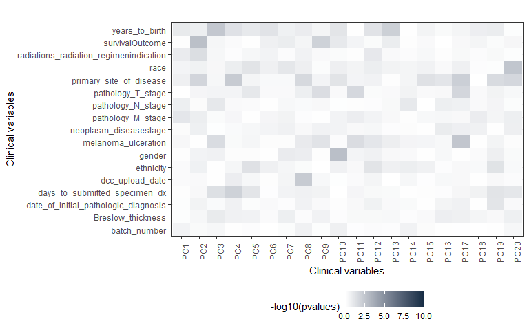

```r
pcaCorrelation(clinical=clinical_skcm2[colnames(subset_logit_met_skcm_corrected),],
               clin_var=clin_var, pca_data=pca_met$x, maxlogPvalue = 10)
```

## 2.3 Characterization of the data: Joint exploration.

Based on first data exploration and pre-process, we know that the most rellevant variables in our omics data sets after batch correction are the primary site of disease, neoplasm disease stage and the survival outcome.

But, how much the different data-types (e.g. different omics) are “explaining the samples in the same way”? To be more specific: are there shared components or not? How many?

The joint exploration will be perofrmed for:

- mRNA + miRNA
- mRNA + methylation

### 2.3.1 Data scaling

Before start the multi-omic approach, mean centred of each feature and the data set normalization to unit sum of squares (forbenious normalization) is recommended to make more comparabable the different omics data-types.

```r
#Calculate Forbenious normalization
frobenius_rna <- norm(as.matrix(subset_log2_rna_skcm_corrected), type="F")
frobenius_mirna <- norm(as.matrix(subset_log2_mirna_skcm_corrected), type="F")
frobenius_met <- norm(as.matrix(subset_logit_met_skcm_corrected), type="F")

#Mean-centring and division by Frobenius normalization factor
rna_skcm_norm <- t(scale(t(subset_log2_rna_skcm_corrected), scale=FALSE))/frobenius_rna
mirna_skcm_norm <- t(scale(t(subset_log2_mirna_skcm_corrected), scale=FALSE))/frobenius_mirna
met_skcm_norm <- t(scale(t(subset_logit_met_skcm_corrected), scale=FALSE))/frobenius_met

##Mean-centring without Frobenius normalization
rna_skcm_norm2 <- t(scale(t(subset_log2_rna_skcm_corrected), scale=FALSE))
mirna_skcm_norm2 <- t(scale(t(subset_log2_mirna_skcm_corrected), scale=FALSE))
met_skcm_norm2 <- t(scale(t(subset_logit_met_skcm_corrected), scale=FALSE))
```

### 2.3.2 Model selection

Now, we are ready to explore if there are share components between data-types.

The first step is to determine the number of shared/common and individual components between omics.

How to determine these numbers is still an open question nowadays, so the user can explore different methods like jive, pca-gca and pESCA, between others. Following, we show how to perform the model selection based on these three methods.

#### 2.3.2.1 JIVE

```r
# Load require packages
library(r.jive)
```

```r
#Using r.jive

####################################################
## mRNA + miRNA (already centered and normalized) ##
####################################################
Data <- list(mRNA=rna_skcm_norm,
             miRNA=mirna_skcm_norm)
rjive_rna_mirna <- jive(Data, scale = FALSE, center = FALSE)


##########################################################
## mRNA + methylation (already centered and normalized) ##
##########################################################
Data <- list(mRNA=rna_skcm_norm,
              met=met_skcm_norm)
rjive_rna_met <- jive(Data, scale = FALSE, center = FALSE)
```

#### 2.3.2.2 PCA-GCA

```r
# Load require packages
library(RegularizedSCA)

#Using pca-gca

####################################################
## mRNA + miRNA (already centered and normalized) ##
####################################################
data <- cbind(t(rna_skcm_norm),
              t(mirna_skcm_norm))

# Number of variables
Jk <- c(nrow(rna_skcm_norm), nrow(mirna_skcm_norm))

# Select components
pca_gca(data, Jk, cor_min = .7)

##########################################################
## mRNA + methylation (already centered and normalized) ##
##########################################################
data <- cbind(t(rna_skcm_norm),
              t(met_skcm_norm))

# Number of variables
Jk <- c(nrow(rna_skcm_norm), nrow(met_skcm_norm))

# Select components
pca_gca(data, Jk, cor_min = .7)
```

#### 2.3.2.3 pESCA

```r
# Load require packages
library(RpESCA)
library(RSpectra)

#Using RpESCA

################################################
## mRNA + miRNA (already centered)            ##
################################################

dataSets <- list(rna=t(rna_skcm_norm2),
                 mirna=t(mirna_skcm_norm2))

dataTypes <- 'GG'

# used parameters
opts <- list()
opts$tol_obj <- 1E-4
opts$quiet <- 1

# save the estimated alphas, selected number of PCs and cvErrors
alphas <- rep(NA,2)
R_selected_list <- as.list(1:2)
cvErrors_list <- as.list(1:2)

# alpha estimation for each data set
for (i in 1:length(dataSets)){
  # index ith data set
  X <- dataSets[[i]]

  # alpha estimation procedure
  alpha_est <- alpha_estimation(X,K=3,Rs = 5:20,opts=opts)
  alphas[i] <- alpha_est$alphas_mean
  R_selected_list[[i]] <- alpha_est$R_CV
  cvErrors_list[[i]] <- alpha_est$cvErrors
}
names(alphas) <- paste0('alpha', 1:2)

## Setting the parameters for the pESCA model

# concave function and its hyper-parameter
fun_concave <- 'gdp'; gamma <- 1;
penalty = 'L2' # concave L2 norm penalty

# Parameters of a pESCA with concave L2norm penalty model
opts <- list()
opts$gamma <- gamma  # hyper-parameter for the used penalty
opts$rand_start <- 0
opts$tol_obj <- 1e-6 # stopping criteria
opts$maxit   <- 500
opts$alphas  <- alphas
#opts$R # components used Default 0.5*min(I,J) - Minimum number of variables.
opts$thr_path <- 0 # generaint thresholding path or not
opts$quiet <- 1

# Model selection pESCA conave L2 norm penalty
nTries <- 15
lambdas_CV <- log10_seq(from=1, to=500, length.out=nTries)

result_CV <- pESCA_CV(dataSets, dataTypes,
                      lambdas_CV,
                      penalty=penalty,
                      fun_concave=fun_concave,
                      opts=opts)


# select the model with minimum CV error
index_min_cv <- which.min(result_CV$cvErrors_mat[,1])

# cvErrors during the model selection process
result_CV$cvErrors_mat

# selected value of lambda
lambdas_CV[index_min_cv]

# fit the final model
lambdas_opt <- rep(lambdas_CV[index_min_cv],length(dataSets))
opts_opt <- result_CV$inits[[index_min_cv]]
opts_opt$tol_obj <- 1E-8 # using high precision model


pESCA_L2 <- pESCA(dataSets = dataSets,
                          dataTypes = dataTypes,
                          lambdas = lambdas_opt,
                          penalty = penalty,
                          fun_concave= fun_concave,
                          opts = opts_opt)


mu <- pESCA_L2$mu
A <- pESCA_L2$A
B <- pESCA_L2$B
S <- pESCA_L2$S

# estimated variation explained ratios for each data set or the full data set
pESCA_L2$varExpTotals

# estimated variation explained ratios of each PC for each data set or the full data set
pESCA_L2$varExpPCs

#Cut-off 1%
sel1 <- which(pESCA_L2$varExpPCs[1,]>1) #19
sel2 <- which(pESCA_L2$varExpPCs[2,]>1) #8
intersect(sel1,sel2)
# 7 common components
# 12 dist mRNA + 1 miRNA
# Total: 20 components

#Cut-off 5%
sel1 <- which(pESCA_L2$varExpPCs[1,]>5) #4
sel2 <- which(pESCA_L2$varExpPCs[2,]>5) #5
intersect(sel1,sel2)
# 2 common components
# 2 dist mRNA + 3 miRNA
# Total: 7 components


################################################
## mRNA + Methylation (already centered)      ##
################################################

dataSets <- list(rna=t(rna_skcm_norm2),
                 met=t(met_skcm_norm2))

dataTypes <- 'GG'

# used parameters
opts <- list()
opts$tol_obj <- 1E-4
opts$quiet <- 1

# save the estimated alphas, selected number of PCs and cvErrors
alphas <- rep(NA,2)
R_selected_list <- as.list(1:2)
cvErrors_list <- as.list(1:2)

# alpha estimation for each data set
for (i in 1:length(dataSets)){
  # index ith data set
  X <- dataSets[[i]]

  # alpha estimation procedure
  alpha_est <- alpha_estimation(X,K=3,Rs = 5:20,opts=opts)
  alphas[i] <- alpha_est$alphas_mean
  R_selected_list[[i]] <- alpha_est$R_CV
  cvErrors_list[[i]] <- alpha_est$cvErrors
}
names(alphas) <- paste0('alpha', 1:2)

## Setting the parameters for the pESCA model

# concave function and its hyper-parameter
fun_concave <- 'gdp'; gamma <- 1;
penalty = 'L2' # concave L2 norm penalty

# Parameters of a pESCA with concave L2norm penalty model
opts <- list()
opts$gamma <- gamma  # hyper-parameter for the used penalty
opts$rand_start <- 0
opts$tol_obj <- 1e-6 # stopping criteria
opts$maxit   <- 500
opts$alphas  <- alphas
#opts$R  # components used Default 0.5*min(I,J) - Minimum number of variables.
opts$thr_path <- 0 # generaint thresholding path or not
opts$quiet <- 1

# Model selection pESCA conave L2 norm penalty
nTries <- 15
lambdas_CV <- log10_seq(from=1, to=500, length.out=nTries)

result_CV <- pESCA_CV(dataSets, dataTypes,
                      lambdas_CV,
                      penalty=penalty,
                      fun_concave=fun_concave,
                      opts=opts)


# select the model with minimum CV error
index_min_cv <- which.min(result_CV$cvErrors_mat[,1])

# cvErrors during the model selection process
result_CV$cvErrors_mat

# selected value of lambda
lambdas_CV[index_min_cv]

# fit the final model
lambdas_opt <- rep(lambdas_CV[index_min_cv],length(dataSets))
opts_opt <- result_CV$inits[[index_min_cv]]
opts_opt$tol_obj <- 1E-8 # using high precision model


pESCA_L2 <- pESCA(dataSets = dataSets,
                          dataTypes = dataTypes,
                          lambdas = lambdas_opt,
                          penalty = penalty,
                          fun_concave= fun_concave,
                          opts = opts_opt)

mu <- pESCA_L2$mu
A <- pESCA_L2$A
B <- pESCA_L2$B
S <- pESCA_L2$S

# estimated variation explained ratios for each data set or the full data set
pESCA_L2$varExpTotals

# estimated variation explained ratios of each PC for each data set or the full data set
pESCA_L2$varExpPCs

#Cut-off 1%
sel1 <- which(pESCA_L2$varExpPCs[1,]>1) #5
sel2 <- which(pESCA_L2$varExpPCs[2,]>1) #17
intersect(sel1,sel2)
# 4 common components
# 1 dist mRNA + 13 methylation
# Total: 18 components

#Cut-off 5%
sel1 <- which(pESCA_L2$varExpPCs[1,]>5) #4
sel2 <- which(pESCA_L2$varExpPCs[2,]>5) #3
intersect(sel1,sel2)
# 1 common components
# 3 dist mRNA + 2 methylation
# Total: 6 components
```

Here, there is the table summarizing the output of the different methods.

[output not shown]

As we can observe, the results from the different methods diverge. We are not able to recommend a method but, in general, we can say that it seems that there’s a small part of data variation that is shared between omics. To follow with the analysis, we will explore the omicsPCA based on the output from pESCA (1%).

### 2.3.3 Sub-space recovery

Based on the number of components identified (pESCA) we can recover the subspace.

It is interesting to take a look on the common and distinctive components identified thorugh this method.

```r
################################################
## mRNA + miRNA (already centered)            ##
################################################

# Explore the common and distinctive components and those variation explained
# Common components
cc <- intersect(sel1,sel2)
pESCA_L2$varExpPCs[,cc]
```

```
##              PC1       PC2      PC4       PC5      PC6      PC8     PC16
## X_1    11.579509 10.533584 5.419378  3.820993 3.025871 1.957098 1.025214
## X_2     8.374504  5.984612 4.326859 10.239672 2.992696 5.973369 5.732144
## X_full 11.408189 10.290424 5.360978  4.164097 3.024098 2.171783 1.276817
```

```r
# Distinctive components
dist_rna <- sel1[!sel1%in%cc] #rna
pESCA_L2$varExpPCs[,dist_rna]
```

```
##             PC3      PC7      PC9     PC10     PC11     PC12     PC13     PC14
## X_1    6.596958 2.900797 1.739578 1.769607 1.877849 1.629797 1.427576 1.306367
## X_2    0.000000 0.000000 0.000000 0.000000 0.000000 0.000000 0.000000 0.000000
## X_full 6.244325 2.745738 1.646591 1.675015 1.777470 1.542678 1.351267 1.236537
##            PC15    PC17     PC18      PC20
## X_1    1.244135 1.18888 1.103844 1.0237636
## X_2    0.000000 0.00000 0.000000 0.0000000
## X_full 1.177631 1.12533 1.044839 0.9690394
```

```r
dist_mirna <- sel2[!sel2%in%cc] #mirna
pESCA_L2$varExpPCs[,dist_mirna]
```

```
##      X_1      X_2   X_full
## 0.000000 3.666469 0.195987
```

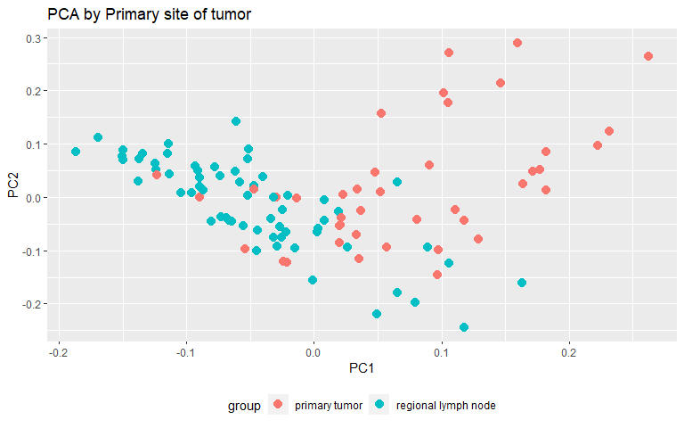

```r
# Keep de common and distinctive components
common_pc <- pESCA_L2$A[,cc]
colnames(common_pc) <- colnames(pESCA_L2$varExpPCs[,cc])

dist_rna_pc <- pESCA_L2$A[,dist_rna]
colnames(dist_rna_pc) <- names(dist_rna)

dist_mirna_pc <- data.frame(pESCA_L2$A[,dist_mirna])
colnames(dist_mirna_pc) <- names(dist_mirna)


# metadata for common samples
clin <- clinical_skcm2

# PCA plot
require(ggplot2)

df <- as.data.frame(common_pc)
df$group <- clin$primary_site_of_disease
df$batch <- clin$batch_number

#plot of first common components by gene expression subtype
p <- ggplot(df,aes_string("PC1","PC2",color="group"))
p + geom_point(size=5, shape=20) + ggtitle("PCA by Primary site of tumor") + theme(legend.position="bottom")
```

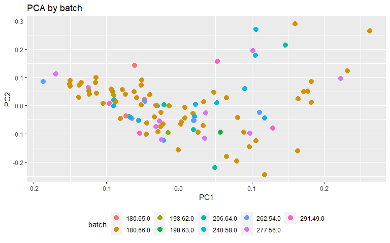

```r
#plot of first common components by batch
p <- ggplot(df,aes_string("PC1","PC2",color="batch"))
p + geom_point(size=5, shape=20) + ggtitle("PCA by batch") + theme(legend.position="bottom")
```

Let’s explore how relate these common and distinctive components with the clinical variables.

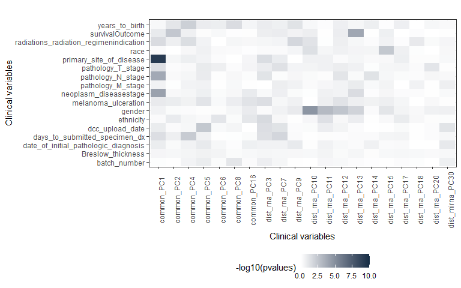

```r
df <- data.frame(common_pc,dist_rna_pc,dist_mirna_pc)
colnames(df) <- c(paste("common_",colnames(common_pc),sep=""),
                  paste("dist_rna_",colnames(dist_rna_pc),sep=""),
                  paste("dist_mirna_",colnames(dist_mirna_pc),sep=""))

pcaCorrelation(clinical=clin, clin_var, df, maxlogPvalue =10, maxPC=ncol(df), pc.names=TRUE)
```

Based on these results, it seems that there are some information shared between mRNA and miRNA related with `primary_site_of_disease`.

```r
################################################
## mRNA + methylation (already centered)      ##
################################################

# Explore the common and distinctive components and those variation explained
# Common components
cc <- intersect(sel1,sel2)
pESCA_L2$varExpPCs[,cc]
```

```
##              PC2      PC5      PC7      PC8
## X_1     7.558119 6.496145 3.531933 9.899786
## X_2    11.129553 3.020236 1.436063 1.080839
## X_full 10.869422 3.273409 1.588719 1.723182
```

```r
# Distinctive components
dist_rna <- sel1[!sel1%in%cc] #rna
pESCA_L2$varExpPCs[,dist_rna]
```

```
##       X_1       X_2    X_full
## 6.4767897 0.0000000 0.4717474
```

```r
dist_met <- sel2[!sel2%in%cc] #met
pESCA_L2$varExpPCs[,dist_met]
```

```
##             PC1      PC3      PC4      PC6      PC9     PC10     PC11     PC12
## X_1     0.00000 0.000000 0.000000 0.000000 0.000000 0.000000 0.000000 0.000000
## X_2    16.99856 7.476659 3.274144 2.210317 1.807941 1.563034 1.459798 1.348897
## X_full 15.76044 6.932084 3.035667 2.049325 1.676257 1.449188 1.353472 1.250648
##            PC13     PC14     PC15     PC16      PC17
## X_1    0.000000 0.000000 0.000000 0.000000 0.0000000
## X_2    1.275617 1.187714 1.131896 1.080992 1.0539083
## X_full 1.182705 1.101205 1.049452 1.002256 0.9771452
```

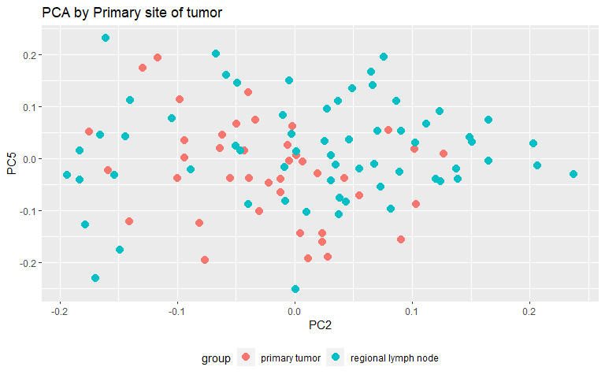

```r
# Keep de common and distinctive components
common_pc <- pESCA_L2$A[,cc]
colnames(common_pc) <- colnames(pESCA_L2$varExpPCs[,cc])

dist_rna_pc <- data.frame(pESCA_L2$A[,dist_rna])
colnames(dist_rna_pc) <- names(dist_rna)

dist_met_pc <- pESCA_L2$A[,dist_met]
colnames(dist_met_pc) <- names(dist_met)


# metadata for common samples
clin <- clinical_skcm2

# PCA plot
require(ggplot2)

df <- as.data.frame(common_pc)
df$group <- clin$primary_site_of_disease
df$batch <- clin$batch_number


#plot of first common components by gene expression subtype
p <- ggplot(df,aes_string("PC2","PC5",color="group"))
p + geom_point(size=5, shape=20) + ggtitle("PCA by Primary site of tumor") + theme(legend.position="bottom")
```

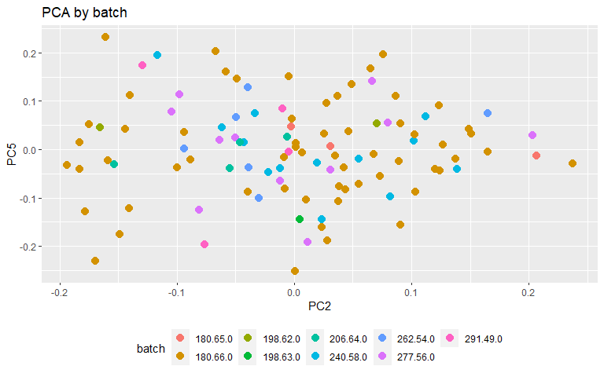

```r
#plot of first common components by batch
p <- ggplot(df,aes_string("PC2","PC5",color="batch"))
p + geom_point(size=5, shape=20) + ggtitle("PCA by batch") + theme(legend.position="bottom")
```

Let’s explore how relate these common and distinctive components with the clinical variables.

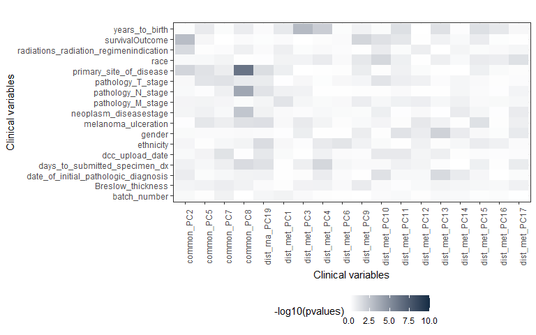

```r
df <- data.frame(common_pc,dist_rna_pc,dist_met_pc)
colnames(df) <- c(paste("common_",colnames(common_pc),sep=""),
                  paste("dist_rna_",colnames(dist_rna_pc),sep=""),
                  paste("dist_met_",colnames(dist_met_pc),sep=""))

pcaCorrelation(clinical=clin, clin_var, df, maxlogPvalue =10, maxPC=ncol(df), pc.names=TRUE)
```

Within the common components we can identify a significant association with the `primary site of disease` and `survivalOutcome`.

## 2.4 Integrative differential analysis by NPC

Now, we want to identify genes that, according to all modalities considered as a whole (mRNA, miRNA, methylation, etc.), are either deregulated or associated to an outcome of interest.

From the previous steps (individual omics exploration and joint exploration) we will be considering (1) which co-variates are necessary to include and (2) which analysis do we want to perform.

Using omicsNPC we can explore the combination of two omics. The NPC will provide two outcomes:

- The features that are differentiated in both omics, therefore we are looking into coordinated effects.
- The features that are differentiated in only one of the omics.

### 2.4.1 mRNA + miRNA

First of all we need to have a mapping file mathcing omics.

#### 2.4.1.1 Mapping file

```r
#Load the mapping info
#load('hsa-vtm-gene.Rdata')
#the mapping can be obtained using SpidermiR package

#Identify the miRBase version of mapping file and data
library(miRNAmeConverter)

miRNAs <- rownames(subset_log2_mirna_skcm_corrected)
miRNAs_mapping <- names(id)
nc <- MiRNANameConverter()
assessVersion(nc, miRNAs, verbose = FALSE) #version 16
```

```
##    version frequency
## 1     16.0       638
## 2     17.0       606
## 3     15.0       554
## 4     14.0       436
## 5     13.0       421
## 6     18.0       420
## 7     12.0       416
## 8     11.0       402
## 9     19.0       394
## 10    20.0       331
## 11    21.0       328
## 12    10.1       325
## 13    22.0       314
## 14    10.0       313
## 15     9.2       310
## 16     9.1       309
## 17     9.0       308
## 18     8.2       303
## 19     8.1       303
## 20     8.0       200
## 21     7.1       197
## 22     6.0       130
```

```r
assessVersion(nc, miRNAs_mapping, verbose = FALSE) #version 20
```

```
##    version frequency
## 1     20.0       573
## 2     21.0       569
## 3     22.0       560
## 4     19.0       546
## 5     18.0       533
## 6     17.0       380
## 7     16.0       372
## 8     15.0       359
## 9     14.0       341
## 10    13.0       339
## 11    12.0       338
## 12    11.0       337
## 13    10.1       321
## 14    10.0       314
## 15     9.2       228
## 16     9.1       228
## 17     9.0       227
## 18     8.2       220
## 19     8.1       220
## 20     8.0       181
## 21     7.1       178
## 22     6.0       145
```

```r
#convert miRNA annotation from our miRNA matrix from v.16 to v.20
library(anamiR)
new_mirna_matrix <- miR_converter(subset_log2_mirna_skcm_corrected, remove_old = TRUE, original_version=16, latest_version = 20)
#Original data 898 miRNAs, now 686 miRNAs

#restricting mapping info to measured miRNA
id_mapping <- id[intersect(names(id), rownames(new_mirna_matrix))]
#from the initial 686 miRNA features we get 239 miRNA shared with mapping info

#creating the miRNA association tables
mirna2GeneMap <- stack(id_mapping) #convert in a data.frame. Each line has a gene and one mirna.
names(mirna2GeneMap) <- c('Gene', 'miRNA')
#Dimension: 22,471 x 2

head(mirna2GeneMap)
```

```
##     Gene         miRNA
## 1 AARSD1 hsa-let-7b-5p
## 2   AATF hsa-let-7b-5p
## 3 ABCB10 hsa-let-7b-5p
## 4  ABCB8 hsa-let-7b-5p
## 5  ABCC1 hsa-let-7b-5p
## 6  ABCF1 hsa-let-7b-5p
```

```r
#creating the mRNA association tables
gene_names_rna <- unlist(lapply(strsplit(rownames(subset_log2_rna_skcm_corrected),"\\|"),
                                FUN=function(x){return(x[1])}))
rownames(subset_log2_rna_skcm_corrected) <- gene_names_rna

expr2GeneMap <- data.frame(measurement = gene_names_rna,
                           Gene = gene_names_rna)
#Dimension: 20,225 x 2

#creating the data mapping
dataMappingExprMirna <- combiningMappings(mappings = list(expr = expr2GeneMap,
                                                          mirna = mirna2GeneMap),
                                          retainAll = TRUE, reference = 'Gene');
#Dimension: 21,321 x 3

head(dataMappingExprMirna)
```

```
##      expr           mirna   Gene
## 8     A2M   hsa-miR-98-5p    A2M
## 9     A2M  hsa-miR-122-5p    A2M
## 11 A4GALT hsa-miR-193b-3p A4GALT
## 14   AAAS   hsa-miR-28-5p   AAAS
## 15   AAAS hsa-miR-1296-5p   AAAS
## 16   AAAS hsa-miR-193b-3p   AAAS
```

We can see that based on our mRNA and miRNA analysis, we have 21,321 pairs in total, it corresponds to 9,491 unique genes (46.9% from the whole mRNA dataset) and 239 unique miRNAs (26.6% from the whole miRNA dataset).

Then, we define the relevant clinical variables in each escenario. The variable of interest in the case of SKCM is the `primary_site_of_disease`. Moreover, `years_to_birth` is introduced in the model as a confounder.

```r
clinicalVariables <- list(expr = c('years_to_birth','primary_site_of_disease'),
                          met = c('years_to_birth','primary_site_of_disease'),
                          mirna = c('years_to_birth','primary_site_of_disease'));
```

```r
#restrict the datasets to the elements of the data mapping
exprTMP <- subset_log2_rna_skcm_corrected[unique(dataMappingExprMirna$expr), ]; #9491 x 104

mirnaTMP <- new_mirna_matrix[unique(dataMappingExprMirna$mirna), ]; #239 x 104

#specifying the data types.
dataTypesExprMirna <- c(expr = 'continuous', mirna = 'continuous')

#preparing the datasets
mexpr <- as.matrix(clinical_skcm2[,clinicalVariables[['expr']]])
rownames(mexpr) <- rownames(clinical_skcm2)
colnames(mexpr) <- clinicalVariables[['expr']]

exprTMP <- createOmicsExpressionSet(Data = as.matrix(exprTMP),
                                    pData = mexpr)

mmirn <- as.matrix(clinical_skcm2[,clinicalVariables[['mirna']]])
rownames(mmirn) <- rownames(clinical_skcm2)
colnames(mmirn) <- clinicalVariables[['mirna']]

mirnaTMP <- createOmicsExpressionSet(Data = as.matrix(mirnaTMP),
                                     pData = mmirn)

dataInputExprMirna <- list(expr = exprTMP, mirna = mirnaTMP)
```

#### 2.4.1.2 Parametric Combination

```r
set.seed(12345)
omicsPCRes_cPC <- omicsPC(dataInput = dataInputExprMirna,
                       dataMapping = dataMappingExprMirna,
                       dataTypes = dataTypesExprMirna,
                       verbose = TRUE)
```

The output of `omicsPC` provides information regarding p-value and adjusted p-value from both individual and combined analysis.

```r
res <- omicsPCRes_cPC
str(res)
```

```
## List of 4
##  $ expr     :'data.frame':   9491 obs. of  6 variables:
##   ..$ logFC    : num [1:9491] -3.356 0.445 0.125 0.252 -2.491 ...
##   ..$ AveExpr  : num [1:9491] 3.58 6.53 9.79 1.11 1.01 ...
##   ..$ t        : num [1:9491] -3.74 1.394 0.928 0.499 -5.206 ...
##   ..$ P.Value  : num [1:9491] 4.35e-04 1.69e-01 3.57e-01 6.19e-01 2.85e-06 ...
##   ..$ adj.P.Val: num [1:9491] 0.02611 0.7101 0.86608 0.95332 0.00075 ...
##   ..$ B        : num [1:9491] -0.13 -5.27 -5.78 -6.08 4.5 ...
##  $ mirna    :'data.frame':   239 obs. of  6 variables:
##   ..$ logFC    : num [1:239] -6.34e-01 2.48e-01 3.76e-02 -1.81e-03 5.27e-05 ...
##   ..$ AveExpr  : num [1:239] 7.446734 0.309937 5.859169 0.008503 0.000168 ...
##   ..$ t        : num [1:239] -1.75156 1.12416 0.12963 -0.10786 0.00736 ...
##   ..$ P.Value  : num [1:239] 0.0854 0.2659 0.8973 0.9145 0.9942 ...
##   ..$ adj.P.Val: num [1:239] 0.435 0.702 0.995 0.995 0.997 ...
##   ..$ B        : num [1:239] -5.67 -6.54 -7.17 -7.17 -7.18 ...
##  $ pvaluesPC:'data.frame':   21321 obs. of  8 variables:
##   ..$ expr     : chr [1:21321] "A2M" "A2M" "A4GALT" "AAAS" ...
##   ..$ mirna    : chr [1:21321] "hsa-miR-98-5p" "hsa-miR-122-5p" "hsa-miR-193b-3p" "hsa-miR-28-5p" ...
##   ..$ Fisher   : num [1:21321] 0.000416 0.001163 0.437606 0.692071 0.7227 ...
##   ..$ Liptak   : num [1:21321] 0.000446 0.002582 0.586256 0.760884 0.936259 ...
##   ..$ Tippett  : num [1:21321] 0.000869 0.000869 0.337903 0.714267 0.714267 ...
##   ..$ Benjamini: num [1:21321] 0.000869 0.000869 0.337903 0.714267 0.714267 ...
##   ..$ Simes    : num [1:21321] 0.000869 0.000869 0.337903 0.714267 0.714267 ...
##   ..$ Sidak    : num [1:21321] 0.000869 0.000869 0.309358 0.586723 0.586723 ...
##  $ qvaluesPC:'data.frame':   21321 obs. of  8 variables:
##   ..$ expr     : chr [1:21321] "A2M" "A2M" "A4GALT" "AAAS" ...
##   ..$ mirna    : chr [1:21321] "hsa-miR-98-5p" "hsa-miR-122-5p" "hsa-miR-193b-3p" "hsa-miR-28-5p" ...
##   ..$ Fisher   : num [1:21321] 0.0223 0.0478 0.7435 0.8979 0.9167 ...
##   ..$ Liptak   : num [1:21321] 0.0277 0.0861 0.8814 0.9611 1 ...
##   ..$ Tippett  : num [1:21321] 0.0405 0.0405 0.6694 0.9856 0.9856 ...
##   ..$ Benjamini: num [1:21321] 0.0405 0.0405 0.6358 0.9297 0.9297 ...
##   ..$ Simes    : num [1:21321] 0.0405 0.0405 0.6358 0.9297 0.9297 ...
##   ..$ Sidak    : num [1:21321] 0.0405 0.0405 0.6129 0.8096 0.8096 ...
```

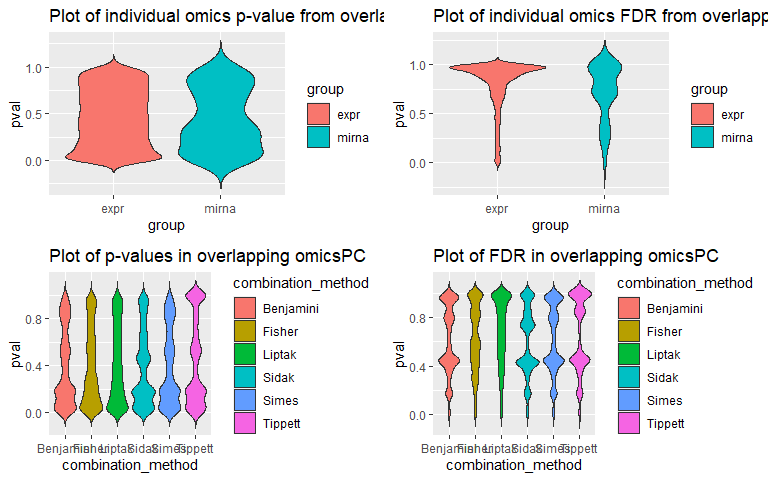

```r
#Nominal p-values plot individual omics
data_plot <- data.frame(pval=c(res$expr[,"P.Value"],res$mirna[,"P.Value"]),
                        group=c(rep(names(res)[1], nrow(res$expr)),
                                rep(names(res)[2], nrow(res$mirna))))

p1 <- ggplot(data_plot, aes(x=group, y=pval, fill=group)) +
  geom_violin(trim=FALSE)+
  labs(title='Plot of individual omics p-value from overlapping samples')

#FDR plot individual omics
data_plot <- data.frame(pval=c(res$expr[,"adj.P.Val"],res$mirna[,"adj.P.Val"]),
                        group=c(rep(names(res)[1], nrow(res$expr)),
                                rep(names(res)[2], nrow(res$mirna))))

p2 <- ggplot(data_plot, aes(x=group, y=pval, fill=group)) +
  geom_violin(trim=FALSE)+
  labs(title='Plot of individual omics FDR from overlapping samples')


#Nominal p-value plot PC
data_plot <- data.frame(pval=unlist(res$pvaluesPC[,-c(1,2)]),
                        combination_method=rep(colnames(res$pvaluesPC[,-c(1,2)]),
                                               each=nrow(res$pvaluesPC)))

p3 <- ggplot(data_plot, aes(x=combination_method, y=pval,
                            fill=combination_method)) +
  geom_violin(trim=FALSE)+
  labs(title='Plot of p-values in overlapping omicsPC')


#FDR plot PC
data_plot <- data.frame(pval=unlist(res$qvaluesPC[,-c(1,2)]),
                        combination_method=rep(colnames(res$qvaluesPC[,-c(1,2)]),
                                               each=nrow(res$qvaluesPC)))

p4 <- ggplot(data_plot, aes(x=combination_method, y=pval,
                            fill=combination_method)) +
  geom_violin(trim=FALSE)+
  labs(title='Plot of FDR in overlapping omicsPC')


grid.arrange(p1, p2, p3, p4, ncol=2, nrow=2)
```

Now, based on FDR results we can check if there are an increase of statistical power when both omics are jointly analyzed.

Note: here we consider significant an FDR<0.05.

```r
#Significant genes or miRNA from individual omics (FDR<0.05)
sig_expr_cPC <- rownames(res$expr)[which(res$expr[,"adj.P.Val"]<0.05)]
# 216 genes

#significant miRNA
(sig_mirna_cPC <- rownames(res$mirna)[which(res$mirna[,"adj.P.Val"]<0.05)])
```

```
## [1] "hsa-miR-1227-3p" "hsa-miR-204-5p"  "hsa-miR-200b-3p" "hsa-miR-200a-3p"
## [5] "hsa-miR-140-5p"  "hsa-miR-202-3p"
```

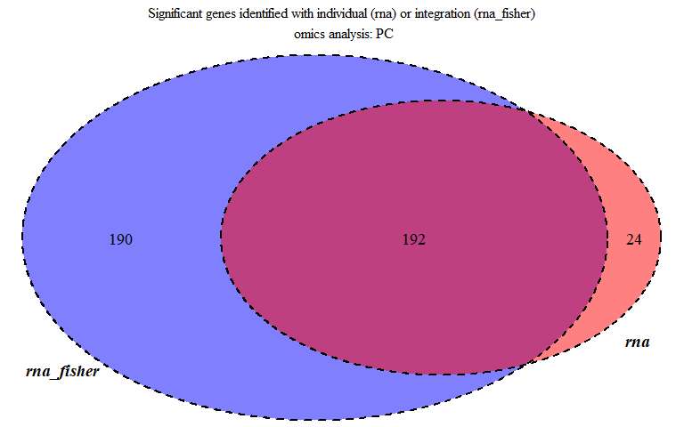

```r
# 6 miRNA

#Significant genes from mRNA + miRNA parametric combination (Fisher, FDR<0.05)
sig_expr_mirna_cPC <- res$qvaluesPC[which(res$qvaluesPC$Fisher<0.05),1:2]
# 529 pairs


#venn diagram
m1 <- list(rna=sig_expr_cPC, rna_fisher=unique(sig_expr_mirna_cPC$expr))

vennPlot1 <- venn.diagram(m1, NULL, fill=c('red','blue'),
                         cat.fontface=4, lty=2, cex=1.2, cat.cex=1.2, main='Significant genes identified with individual (rna) or integration (rna_fisher)\n omics analysis: PC')
grid.newpage()
grid.draw(vennPlot1)
```

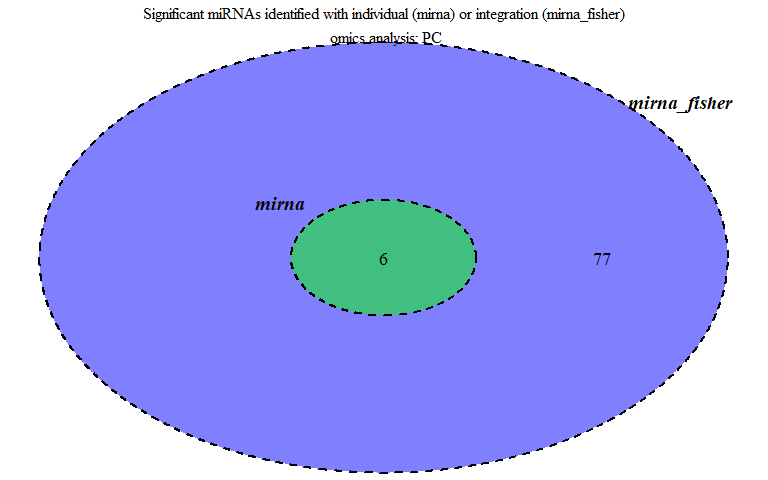

```r
m2 <- list(mirna=sig_mirna_cPC, mirna_fisher=unique(sig_expr_mirna_cPC$mirna))

vennPlot2 <- venn.diagram(m2, NULL, fill=c('green','blue'),
                         cat.fontface=4, lty=2, cex=1.2, cat.cex=1.2, main='Significant miRNAs identified with individual (mirna) or integration (mirna_fisher)\n omics analysis: PC')

grid.newpage()
grid.draw(vennPlot2)
```

We identified new 190 significant genes and 77 new mirnas with the joint exploration.

Here we can see the list of some of the new genes (n=190) identified based on Fisher combination.

```r
setdiff(sig_expr_mirna_cPC$expr,sig_expr_cPC)[1:50]
```

```
##  [1] "ACPP"     "ADAM9"    "AKAP1"    "ALDH3A1"  "ALPL"     "ANAPC5"
##  [7] "AP1S1"    "AP1S2"    "ARHGAP26" "ARHGAP29" "ATP2B1"   "BAP1"
## [13] "BCL2"     "BCL2L2"   "BEX2"     "BIRC2"    "BPTF"     "BRD2"
## [19] "C11orf52" "CASD1"    "CCDC121"  "CCL28"    "CCNE2"    "CCNT2"
## [25] "CDH2"     "CDX2"     "CIDEA"    "CLUAP1"   "COL5A3"   "CPA4"
## [31] "CREB1"    "CREB5"    "CSDE1"    "CSK"      "CTNNB1"   "CTNNBIP1"
## [37] "CXCL3"    "DLX5"     "DNMT1"    "DNPEP"    "E2F3"     "EDEM1"
## [43] "EFNB2"    "ELMO2"    "ELOVL6"   "ENO1"     "EP300"    "ERBB2IP"
## [49] "ETS1"     "EZR"
```

And part of the new miRNAs (n=77) identified based on Fisher combination.

```r
setdiff(sig_expr_mirna_cPC$mirna,sig_mirna_cPC)[1:50]
```

```
##  [1] "hsa-miR-98-5p"   "hsa-miR-122-5p"  "hsa-miR-185-5p"  "hsa-miR-148b-3p"
##  [5] "hsa-let-7b-5p"   "hsa-miR-23a-3p"  "hsa-miR-27b-3p"  "hsa-miR-25-3p"
##  [9] "hsa-miR-21-5p"   "hsa-miR-34a-5p"  "hsa-miR-1226-3p" "hsa-miR-145-5p"
## [13] "hsa-miR-26b-5p"  "hsa-miR-335-5p"  "hsa-miR-331-3p"  "hsa-miR-373-3p"
## [17] "hsa-miR-744-5p"  "hsa-miR-766-3p"  "hsa-miR-186-5p"  "hsa-miR-146a-5p"
## [21] "hsa-miR-203a"    "hsa-miR-215-5p"  "hsa-miR-671-5p"  "hsa-miR-10b-5p"
## [25] "hsa-miR-193b-3p" "hsa-miR-339-5p"  "hsa-miR-224-5p"  "hsa-miR-150-5p"
## [29] "hsa-miR-93-5p"   "hsa-miR-32-5p"   "hsa-let-7d-5p"   "hsa-miR-33a-5p"
## [33] "hsa-miR-17-5p"   "hsa-miR-192-5p"  "hsa-miR-10a-5p"  "hsa-miR-27a-3p"
## [37] "hsa-miR-155-5p"  "hsa-miR-30a-5p"  "hsa-miR-1180-3p" "hsa-miR-340-3p"
## [41] "hsa-miR-148a-3p" "hsa-miR-223-3p"  "hsa-miR-149-5p"  "hsa-miR-451a"
## [45] "hsa-miR-505-3p"  "hsa-miR-31-5p"   "hsa-miR-15a-5p"  "hsa-miR-125a-5p"
## [49] "hsa-miR-342-3p"  "hsa-miR-504-5p"
```

#### 2.4.1.3 Non Parametric Combination

```r
set.seed(12345)

# Setting methods to combine pvalues
combMethods <- c("Fisher", "Liptak", "Tippett")
# Setting number of permutations
numPerms <- 1000
# Setting number of cores
numCores <- 1
# Setting omicsNPC to print out the steps that it performs.
verbose <- TRUE

omicsNPCRes_cNPC_rna_mirna <- omicsNPC(dataInput = dataInputExprMirna,
                         dataMapping = dataMappingExprMirna,
                         dataTypes = dataTypesExprMirna,
                         combMethods = combMethods,
                         numPerms = numPerms,
                         numCores = numCores,
                         verbose = verbose)
```

The output of `omicsNPC` provides information regarding p-value and adjusted p-value from both individual and combined analysis.

```r
res <- omicsNPCRes_cNPC_rna_mirna
str(res)
```

```
## List of 4
##  $ expr      :'data.frame':  9491 obs. of  6 variables:
##   ..$ logFC    : num [1:9491] -3.356 0.445 0.125 0.252 -2.491 ...
##   ..$ AveExpr  : num [1:9491] 3.58 6.53 9.79 1.11 1.01 ...
##   ..$ t        : num [1:9491] -3.74 1.394 0.928 0.499 -5.206 ...
##   ..$ P.Value  : num [1:9491] 4.35e-04 1.69e-01 3.57e-01 6.19e-01 2.85e-06 ...
##   ..$ adj.P.Val: num [1:9491] 0.02611 0.7101 0.86608 0.95332 0.00075 ...
##   ..$ B        : num [1:9491] -0.13 -5.27 -5.78 -6.08 4.5 ...
##  $ mirna     :'data.frame':  239 obs. of  6 variables:
##   ..$ logFC    : num [1:239] -6.34e-01 2.48e-01 3.76e-02 -1.81e-03 5.27e-05 ...
##   ..$ AveExpr  : num [1:239] 7.446734 0.309937 5.859169 0.008503 0.000168 ...
##   ..$ t        : num [1:239] -1.75156 1.12416 0.12963 -0.10786 0.00736 ...
##   ..$ P.Value  : num [1:239] 0.0854 0.2659 0.8973 0.9145 0.9942 ...
##   ..$ adj.P.Val: num [1:239] 0.435 0.702 0.995 0.995 0.997 ...
##   ..$ B        : num [1:239] -5.67 -6.54 -7.17 -7.17 -7.18 ...
##  $ pvaluesNPC:'data.frame':  21321 obs. of  7 variables:
##   ..$ expr             : chr [1:21321] "A2M" "A2M" "A4GALT" "AAAS" ...
##   ..$ mirna            : chr [1:21321] "hsa-miR-98-5p" "hsa-miR-122-5p" "hsa-miR-193b-3p" "hsa-miR-28-5p" ...
##   ..$ perm_pvalue_expr : num [1:21321] 0.000999 0.000999 0.164835 0.348651 0.348651 ...
##   ..$ perm_pvalue_mirna: num [1:21321] 0.0869 0.2937 0.8821 0.7293 0.6843 ...
##   ..$ Fisher           : num [1:21321] 0.002 0.004 0.415 0.589 0.592 ...
##   ..$ Liptak           : num [1:21321] 0.003 0.00799 0.55644 0.55145 0.53746 ...
##   ..$ Tippett          : num [1:21321] 0.002 0.002 0.297 0.575 0.578 ...
##  $ qvaluesNPC:'data.frame':  21321 obs. of  7 variables:
##   ..$ expr             : chr [1:21321] "A2M" "A2M" "A4GALT" "AAAS" ...
##   ..$ mirna            : chr [1:21321] "hsa-miR-98-5p" "hsa-miR-122-5p" "hsa-miR-193b-3p" "hsa-miR-28-5p" ...
##   ..$ perm_qvalue_expr : num [1:21321] 0.0298 0.0298 0.7446 0.8665 0.8665 ...
##   ..$ perm_qvalue_mirna: num [1:21321] 0.325 0.435 0.734 0.719 0.758 ...
##   ..$ Fisher           : num [1:21321] 0.0637 0.073 0.5362 0.6217 0.6157 ...
##   ..$ Liptak           : num [1:21321] 0.0853 0.1233 0.6737 0.6752 0.6571 ...
##   ..$ Tippett          : num [1:21321] 0 0 0.396 0.54 0.54 ...
```

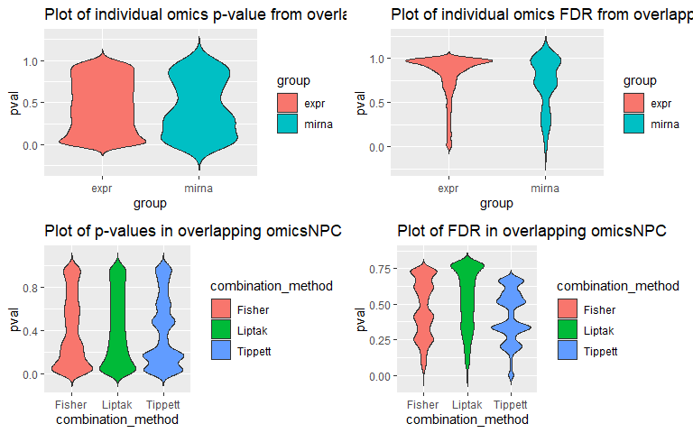

```r
#Nominal p-values plot individual omics
data_plot <- data.frame(pval=c(res$expr[,"P.Value"],res$mirna[,"P.Value"]),
                        group=c(rep(names(res)[1], nrow(res$expr)),
                                rep(names(res)[2], nrow(res$mirna))))

p1 <- ggplot(data_plot, aes(x=group, y=pval, fill=group)) +
  geom_violin(trim=FALSE)+
  labs(title='Plot of individual omics p-value from overlapping samples')

#FDR plot individual omics
data_plot <- data.frame(pval=c(res$expr[,"adj.P.Val"],res$mirna[,"adj.P.Val"]),
                        group=c(rep(names(res)[1], nrow(res$expr)),
                                rep(names(res)[2], nrow(res$mirna))))

p2 <- ggplot(data_plot, aes(x=group, y=pval, fill=group)) +
  geom_violin(trim=FALSE)+
  labs(title='Plot of individual omics FDR from overlapping samples')


#Nominal p-value plot NPC
data_plot <- data.frame(pval=unlist(res$pvaluesNPC[,-c(1:4)]),
                        combination_method=rep(colnames(res$pvaluesNPC[,-c(1:4)]),
                                               each=nrow(res$pvaluesNPC)))

p3 <- ggplot(data_plot, aes(x=combination_method, y=pval, fill=combination_method)) +
  geom_violin(trim=FALSE)+
  labs(title='Plot of p-values in overlapping omicsNPC')


#FDR plot NPC
data_plot <- data.frame(pval=unlist(res$qvaluesNPC[,-c(1:4)]),
                        combination_method=rep(colnames(res$qvaluesNPC[,-c(1:4)]),
                                               each=nrow(res$qvaluesNPC)))

p4 <- ggplot(data_plot, aes(x=combination_method, y=pval, fill=combination_method)) +
  geom_violin(trim=FALSE)+
  labs(title='Plot of FDR in overlapping omicsNPC')


grid.arrange(p1, p2, p3, p4, ncol=2, nrow=2)
```

Now, based on FDR results we can check if there are an increase of statistical power when both omics are jointly analyzed.

Note: here we consider significant a FDR<0.05.

```r
#Significant genes or miRNA from individual omics (FDR<0.05)

#significant genes
sig_expr_cNPC <- rownames(res$expr)[which(res$expr[,"adj.P.Val"]<0.05)]
#216 gene

#significant miRNA
(sig_mirna_cNPC <- rownames(res$mirna)[which(res$mirna[,"adj.P.Val"]<0.05)])
```

```
## [1] "hsa-miR-1227-3p" "hsa-miR-204-5p"  "hsa-miR-200b-3p" "hsa-miR-200a-3p"
## [5] "hsa-miR-140-5p"  "hsa-miR-202-3p"
```

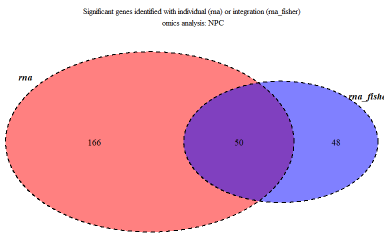

```r
#6 mirna

#Significant genes from mRNA + miRNA non parametric combination (Fisher, FDR<0.05)
sig_expr_mirna_cNPC <- res$qvaluesNPC[which(res$qvaluesNPC[,'Fisher']<0.05),1:2]
#114 pairs


#venn diagram
m1 <- list(rna=sig_expr_cNPC, rna_fisher=unique(sig_expr_mirna_cNPC$expr))

vennPlot1 <- venn.diagram(m1, NULL, fill=c('red','blue'),
                         cat.fontface=4, lty=2, cex=1.2, cat.cex=1.2, main='Significant genes identified with individual (rna) or integration (rna_fisher)\n omics analysis: NPC')
grid.newpage()
grid.draw(vennPlot1)
```

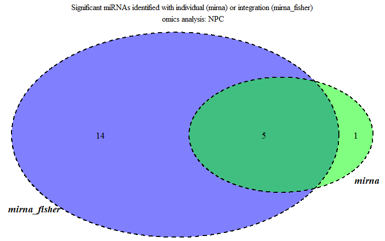

```r
m2 <- list(mirna=sig_mirna_cNPC, mirna_fisher=unique(sig_expr_mirna_cNPC$mirna))

vennPlot2 <- venn.diagram(m2, NULL, fill=c('green','blue'),
                         cat.fontface=4, lty=2, cex=1.2, cat.cex=1.2, main='Significant miRNAs identified with individual (mirna) or integration (mirna_fisher)\n omics analysis: NPC')

grid.newpage()
grid.draw(vennPlot2)
```

For the Non-Parametric approach we get 48 new genes and 14 new miRNAs.

Here we can see the list of new genes (n=48) identified based on Fisher combination.

```r
setdiff(sig_expr_mirna_cNPC$expr,sig_expr_cNPC)
```

```
##  [1] "ADAM9"    "ALPL"     "ATP2B1"   "BAP1"     "CAMK4"    "CCDC88C"
##  [7] "CCL28"    "CREB5"    "CTNNBIP1" "ERBB2IP"  "FLT1"     "FZD1"
## [13] "GIMAP4"   "GPHB5"    "HACL1"    "HDAC4"    "HEMGN"    "HSPA2"
## [19] "ITGB2"    "KLF11"    "KLHL20"   "LBR"      "LIN28B"   "MMP13"
## [25] "POM121"   "POP1"     "PSD3"     "PTPRD"    "RAB38"    "RAB40B"
## [31] "RELA"     "RPTOR"    "SERPINE1" "SNAI2"    "SNAP23"   "SOST"
## [37] "SPNS1"    "TBC1D15"  "TCOF1"    "TERF2IP"  "TFRC"     "TGFBR2"
## [43] "TRAF6"    "UBE2I"    "USP14"    "WASF3"    "XIAP"     "ZEB2"
```

And the new miRNAs (n=14) identified based on Fisher combination.

```r
setdiff(sig_expr_mirna_cNPC$mirna,sig_mirna_cNPC)
```

```
##  [1] "hsa-miR-148b-3p" "hsa-miR-23a-3p"  "hsa-let-7b-5p"   "hsa-miR-744-5p"
##  [5] "hsa-miR-146a-5p" "hsa-miR-215-5p"  "hsa-miR-20a-5p"  "hsa-miR-27a-3p"
##  [9] "hsa-miR-340-3p"  "hsa-miR-148a-3p" "hsa-miR-31-5p"   "hsa-miR-30e-5p"
## [13] "hsa-miR-18a-5p"  "hsa-miR-149-5p"
```

#### 2.4.1.4 Integration strategies comparison

Finally, we can compare the divergences between parametric and non-parametric approaches.

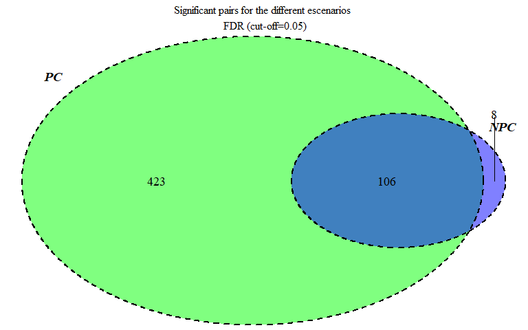

```r
#Significant pairs from different approaches

#parmetric combination of significant pairs
PC <- paste(sig_expr_mirna_cPC$expr,sig_expr_mirna_cPC$mirna, sep=":") #529
#non parmetric combination of significant pairs
NPC <- paste(sig_expr_mirna_cNPC$expr,sig_expr_mirna_cNPC$mirna, sep=":") #114

res_all <- list(PC=PC, NPC=NPC)

vennPlot_m1 <- venn.diagram(res_all, NULL, fill=c("green","blue"),
                            cat.fontface=4, lty=2, cex=1.2, cat.cex=1.2,
                          main="Significant pairs for the different escenarios \n FDR (cut-off=0.05)")

grid.newpage()
grid.draw(vennPlot_m1)
```

If we look in the significant pairs identified by each approach (FDR<0.05), we see that almost all the pairs identified by NPC are also identified by PC, but PC identifies a large number of additonal pairs as significant (n=423).

### 2.4.2 mRNA + Methylation

First of all we need to have a mapping file mathcing omics.

#### 2.4.2.1 Mapping file

```r
#Load the mapping info
#load('methy2GeneMap.RData')
methy2GeneMap <- methy2GeneMap[-40902, ]; #repetition

#restricting mapping info to methylation info
methy2GeneMap_1 <- methy2GeneMap[methy2GeneMap[,1]%in%rownames(subset_logit_met_skcm_corrected),] #from the initial 305,180 methyl features we get 55,774 in common

head(methy2GeneMap_1)
```

```
##          name   Gene
## 15 cg02725885 PPAP2C
## 16 cg09908879 PPAP2C
## 17 cg16691033 PPAP2C
## 18 cg02935627 PPAP2C
## 19 cg12272837 PPAP2C
## 20 cg25697727 PPAP2C
```

```r
#creating the mRNA association tables has been previously created
tail(expr2GeneMap)
```

```
##       measurement      Gene
## 20220      ZYG11B    ZYG11B
## 20221         ZYX       ZYX
## 20222       ZZEF1     ZZEF1
## 20223        ZZZ3      ZZZ3
## 20224   psiTPTE22 psiTPTE22
## 20225        tAKR      tAKR
```

```r
#creating the data mapping (55,729 x 3)
dataMappingExprMet <- combiningMappings(mappings = list(expr = expr2GeneMap,
                                                        met = methy2GeneMap_1),
                                          retainAll = TRUE, reference = 'Gene');

head(dataMappingExprMet)
```

```
##      expr        met   Gene
## 6     A2M cg00134295    A2M
## 8  A4GALT cg07393322 A4GALT
## 9  A4GALT cg01268859 A4GALT
## 10 A4GALT cg20706071 A4GALT
## 11 A4GALT cg26705472 A4GALT
## 12  A4GNT cg23669440  A4GNT
```

We can see that based on our mRNA and methylation analysis, we have 55,729 pairs in total, corresponding to 9,564 unique genes (47.3% from the whole mRNA dataset) and 55,729 unique methylation sites (18% from teh whole methylation dataset).

Then, we define the relevant clinical variables in each escenario. The variable of interest in the case of SKCM is the `primary_site_of_disease`. Moreover, `years_to_birth` is introduced in the model as a confounder.

```r
clinicalVariables <- list(expr = c('years_to_birth','primary_site_of_disease'),
                          met = c('years_to_birth','primary_site_of_disease'),
                          mirna = c('years_to_birth','primary_site_of_disease'));
```

```r
#restrict the datasets to the elements of the data mapping
exprTMP <- subset_log2_rna_skcm_corrected[unique(dataMappingExprMet$expr),]
#Dimension: 9564 x 104

metTMP <- subset_logit_met_skcm_corrected[unique(dataMappingExprMet$met),]
#Dimension: 55729 x 104

#specifying the data types.
dataTypesExprMet <- c(expr = 'continuous', met = 'continuous')


#preparing the datasets
mexpr <- as.matrix(clinical_skcm2[,clinicalVariables[['expr']]])
rownames(mexpr) <- rownames(clinical_skcm2)
colnames(mexpr) <- clinicalVariables[['expr']]

exprTMP <- createOmicsExpressionSet(Data = as.matrix(exprTMP),
                                    pData = mexpr)

mmet <- as.matrix(clinical_skcm2[,clinicalVariables[['met']]])
rownames(mmet) <- rownames(clinical_skcm2)
colnames(mmet) <- clinicalVariables[['met']]

metTMP <- createOmicsExpressionSet(Data = as.matrix(metTMP),
                                     pData = mmet)

dataInputExprMet <- list(expr = exprTMP, met = metTMP)
```

#### 2.4.2.2 Parametric Combination

```r
set.seed(12345)
omicsPCRes_cPC <- omicsPC(dataInput = dataInputExprMet,
                       dataMapping = dataMappingExprMet,
                       dataTypes = dataTypesExprMet,
                       verbose = TRUE)
```

The output of `omicsPC` provides information regarding p-value and adjusted p-value from both individual and combined analysis.

```r
res <- omicsPCRes_cPC
str(res)
```

```
## List of 4
##  $ expr     :'data.frame':   9564 obs. of  6 variables:
##   ..$ logFC    : num [1:9564] -3.356 0.445 0.119 0.125 0.252 ...
##   ..$ AveExpr  : num [1:9564] 3.579 6.529 0.686 9.792 1.109 ...
##   ..$ t        : num [1:9564] -3.737 1.393 0.784 0.928 0.499 ...
##   ..$ P.Value  : num [1:9564] 0.000439 0.169274 0.436072 0.357572 0.619693 ...
##   ..$ adj.P.Val: num [1:9564] 0.0213 0.6734 0.8876 0.8515 0.9487 ...
##   ..$ B        : num [1:9564] -0.15 -5.29 -5.92 -5.8 -6.1 ...
##  $ met      :'data.frame':   55729 obs. of  6 variables:
##   ..$ logFC    : num [1:55729] -0.381 -0.588 -0.67 -0.272 -0.151 ...
##   ..$ AveExpr  : num [1:55729] -1.84 -0.979 -1.33 -2.729 -4.22 ...
##   ..$ t        : num [1:55729] -1.157 -1.562 -1.212 -0.443 -0.459 ...
##   ..$ P.Value  : num [1:55729] 0.252 0.124 0.231 0.659 0.648 ...
##   ..$ adj.P.Val: num [1:55729] 0.754 0.636 0.738 0.928 0.925 ...
##   ..$ B        : num [1:55729] -5.07 -4.6 -5.02 -5.58 -5.57 ...
##  $ pvaluesPC:'data.frame':   55729 obs. of  8 variables:
##   ..$ expr     : chr [1:55729] "A2M" "A4GALT" "A4GALT" "A4GALT" ...
##   ..$ met      : chr [1:55729] "cg00134295" "cg07393322" "cg01268859" "cg20706071" ...
##   ..$ Fisher   : num [1:55729] 0.00112 0.10199 0.16559 0.3563 0.35205 ...
##   ..$ Liptak   : num [1:55729] 0.00237 0.06757 0.11546 0.34954 0.34148 ...
##   ..$ Tippett  : num [1:55729] 0.000878 0.247688 0.338549 0.338549 0.338549 ...
##   ..$ Benjamini: num [1:55729] 0.000878 0.169274 0.230509 0.338549 0.338549 ...
##   ..$ Simes    : num [1:55729] 0.000878 0.169274 0.230509 0.338549 0.338549 ...
##   ..$ Sidak    : num [1:55729] 0.000878 0.23235 0.309895 0.309895 0.309895 ...
##  $ qvaluesPC:'data.frame':   55729 obs. of  8 variables:
##   ..$ expr     : chr [1:55729] "A2M" "A4GALT" "A4GALT" "A4GALT" ...
##   ..$ met      : chr [1:55729] "cg00134295" "cg07393322" "cg01268859" "cg20706071" ...
##   ..$ Fisher   : num [1:55729] 0.0467 0.4763 0.5752 0.7663 0.7632 ...
##   ..$ Liptak   : num [1:55729] 0.085 0.425 0.521 0.774 0.769 ...
##   ..$ Tippett  : num [1:55729] 0.043 0.71 0.797 0.797 0.797 ...
##   ..$ Benjamini: num [1:55729] 0.043 0.589 0.66 0.749 0.749 ...
##   ..$ Simes    : num [1:55729] 0.043 0.589 0.66 0.749 0.749 ...
##   ..$ Sidak    : num [1:55729] 0.043 0.666 0.729 0.729 0.729 ...
```

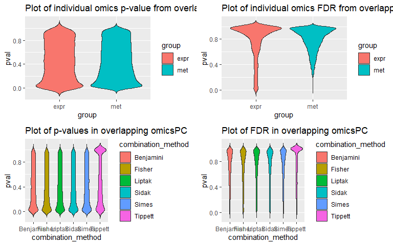

```r
#Nominal p-values plot individual omics
data_plot <- data.frame(pval=c(res$expr[,"P.Value"],res$met[,"P.Value"]),
                        group=c(rep(names(res)[1], nrow(res$expr)),
                                rep(names(res)[2], nrow(res$met))))

p1 <- ggplot(data_plot, aes(x=group, y=pval, fill=group)) +
  geom_violin(trim=FALSE)+
  labs(title='Plot of individual omics p-value from overlapping samples')

#FDR plot individual omics
data_plot <- data.frame(pval=c(res$expr[,"adj.P.Val"],res$met[,"adj.P.Val"]),
                        group=c(rep(names(res)[1], nrow(res$expr)),
                                rep(names(res)[2], nrow(res$met))))

p2 <- ggplot(data_plot, aes(x=group, y=pval, fill=group)) +
  geom_violin(trim=FALSE)+
  labs(title='Plot of individual omics FDR from overlapping samples')


#Nominal p-value plot PC
data_plot <- data.frame(pval=unlist(res$pvaluesPC[,-c(1,2)]),
                        combination_method=rep(colnames(res$pvaluesPC[,-c(1,2)]),
                                               each=nrow(res$pvaluesPC)))

p3 <- ggplot(data_plot, aes(x=combination_method, y=pval,
                            fill=combination_method)) +
  geom_violin(trim=FALSE)+
  labs(title='Plot of p-values in overlapping omicsPC')


#FDR plot PC
data_plot <- data.frame(pval=unlist(res$qvaluesPC[,-c(1,2)]),
                        combination_method=rep(colnames(res$qvaluesPC[,-c(1,2)]),
                                               each=nrow(res$qvaluesPC)))

p4 <- ggplot(data_plot, aes(x=combination_method, y=pval,
                            fill=combination_method)) +
  geom_violin(trim=FALSE)+
  labs(title='Plot of FDR in overlapping omicsPC')


grid.arrange(p1, p2, p3, p4, ncol=2, nrow=2)
```

Now, based on FDR results we can check if there are an increase of statistical power when both omics are jointly analyzed.

Note: here we consider significant an FDR<0.05.

```r
#Significant genes or methyl from individual omics (FDR<0.05)

#significant genes
sig_expr_cPC <- rownames(res$expr)[which(res$expr[,"adj.P.Val"]<0.05)]
# 216 gene

#significant methyl
(sig_met_cPC <- rownames(res$met)[which(res$met[,"adj.P.Val"]<0.05)])
```

```
##  [1] "cg11740099" "cg07286123" "cg18267489" "cg10578007" "cg10018632"
##  [6] "cg21023001" "cg03662648" "cg21037265" "cg00862588" "cg18827221"
## [11] "cg03053826" "cg08299521"
```

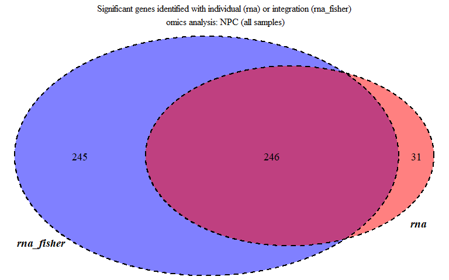

```r
# 12 methylation sites

#Significant genes from mRNA + miRNA non parametric combination (Fisher, FDR<0.05)
sig_expr_met_cPC <- res$qvaluesPC[which(res$qvaluesPC[,'Fisher']<0.05),1:2]
# 1,418 pairs

#venn diagram
m1 <- list(rna=sig_expr_cPC, rna_fisher=unique(sig_expr_met_cPC$expr))

vennPlot1 <- venn.diagram(m1, NULL, fill=c('red','blue'),
                         cat.fontface=4, lty=2, cex=1.2, cat.cex=1.2, main='Significant genes identified with individual (rna) or integration (rna_fisher)\n omics analysis: NPC (all samples)')
grid.newpage()
grid.draw(vennPlot1)
```

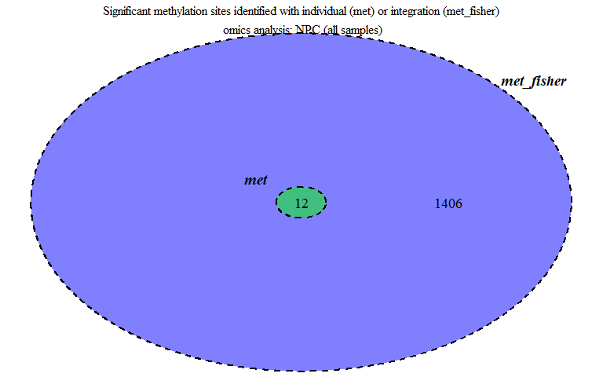

```r
m2 <- list(met=sig_met_cPC, met_fisher=unique(sig_expr_met_cPC$met))

vennPlot2 <- venn.diagram(m2, NULL, fill=c('green','blue'),
                         cat.fontface=4, lty=2, cex=1.2, cat.cex=1.2, main='Significant methylation sites identified with individual (met) or integration (met_fisher)\n omics analysis: NPC (all samples)')

grid.newpage()
grid.draw(vennPlot2)
```

We identified new 245 significant genes and 1,406 new mathylation sites with the joint exploration.

Here we can see the list of some of the new genes (n=245) identified based on Fisher combination.

```r
setdiff(sig_expr_met_cPC$expr,sig_expr_cPC)[1:50]
```

```
##  [1] "ACR"       "ADORA1"    "AHNAK2"    "ALDH3A1"   "ALLC"      "ALOX5AP"
##  [7] "ALPK3"     "ALX4"      "AMIGO2"    "APOBEC3F"  "APOF"      "ARHGAP25"
## [13] "ARHGDIA"   "ARID5A"    "ATP2C2"    "AVPR1B"    "C20orf195" "C9orf156"
## [19] "CA7"       "CALCA"     "CCBP2"     "CCDC88C"   "CCL22"     "CCL24"
## [25] "CCNA1"     "CCR1"      "CCR5"      "CCR7"      "CCT6B"     "CD22"
## [31] "CD37"      "CD6"       "CD63"      "CD79B"     "CD80"      "CD93"
## [37] "CEACAM21"  "CECR5"     "CHRND"     "CLDN4"     "CLIC3"     "CMKLR1"
## [43] "CNR2"      "CNTFR"     "COCH"      "CROCC"     "CRYBA4"    "CRYGB"
## [49] "CYFIP2"    "CYTL1"
```

And part of the new methylation sites (n=1,406) identified based on Fisher combination.

```r
setdiff(sig_expr_met_cPC$met,sig_met_cPC)[1:50]
```

```
##  [1] "cg00134295" "cg24822001" "cg12832630" "cg21475256" "cg14121103"
##  [6] "cg19150852" "cg23239109" "cg03626746" "cg02059996" "cg13606015"
## [11] "cg17200204" "cg25232725" "cg26034629" "cg05615487" "cg24287438"
## [16] "cg11773720" "cg19962990" "cg16457786" "cg22388954" "cg21438101"
## [21] "cg15458338" "cg18319029" "cg08132931" "cg11220663" "cg11341981"
## [26] "cg01133446" "cg06960824" "cg20959872" "cg22087450" "cg00443276"
## [31] "cg26095296" "cg23413349" "cg06025938" "cg18405900" "cg12448860"
## [36] "cg25263140" "cg12674357" "cg19343088" "cg27632402" "cg00974935"
## [41] "cg21079345" "cg02215070" "cg14629509" "cg06864853" "cg04663564"
## [46] "cg13801416" "cg09957386" "cg18957070" "cg24482246" "cg19188632"
```

#### 2.4.2.3 Non Parametric Combination

```r
set.seed(12345)

# Setting methods to combine pvalues
combMethods <- c("Fisher", "Liptak", "Tippett")
# Setting number of permutations
numPerms <- 1000
# Setting number of cores
numCores <- 1
# Setting omicsNPC to print out the steps that it performs.
verbose <- TRUE

omicsNPCRes_cNPC <- omicsNPC(dataInput = dataInputExprMet,
                         dataMapping = dataMappingExprMet,
                         dataTypes = dataTypesExprMet,
                         combMethods = combMethods,
                         numPerms = numPerms,
                         numCores = numCores,
                         verbose = verbose)
```

The output of `omicsNPC` provides information regarding p-value and adjusted p-value from both individual and combined analysis.

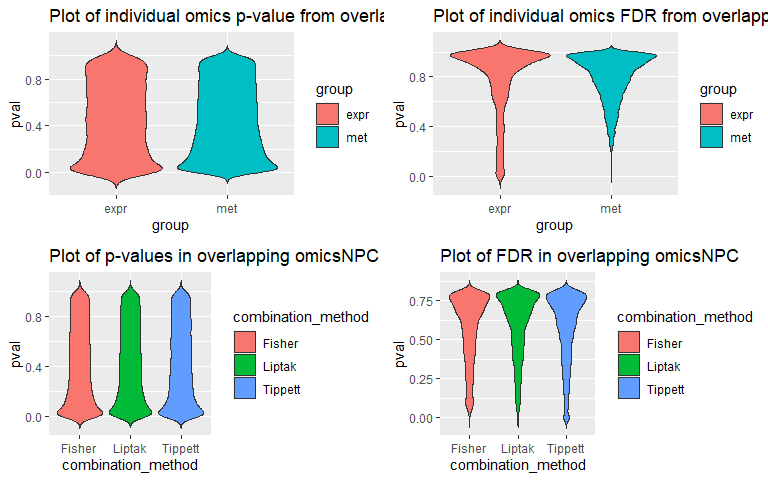

```r
res <- omicsNPCRes_cNPC_rna_met

#Nominal p-values plot individual omics
data_plot <- data.frame(pval=c(res$expr[,"P.Value"],res$met[,"P.Value"]),
                        group=c(rep(names(res)[1], nrow(res$expr)),
                                rep(names(res)[2], nrow(res$met))))

p1 <- ggplot(data_plot, aes(x=group, y=pval, fill=group)) +
  geom_violin(trim=FALSE)+
  labs(title='Plot of individual omics p-value from overlapping samples')

#FDR plot individual omics
data_plot <- data.frame(pval=c(res$expr[,"adj.P.Val"],res$met[,"adj.P.Val"]),
                        group=c(rep(names(res)[1], nrow(res$expr)),
                                rep(names(res)[2], nrow(res$met))))

p2 <- ggplot(data_plot, aes(x=group, y=pval, fill=group)) +
  geom_violin(trim=FALSE)+
  labs(title='Plot of individual omics FDR from overlapping samples')


#Nominal p-value plot NPC
data_plot <- data.frame(pval=unlist(res$pvaluesNPC[,-c(1:4)]),
                        combination_method=rep(colnames(res$pvaluesNPC[,-c(1:4)])
                                               , each=nrow(res$pvaluesNPC)))

p3 <- ggplot(data_plot, aes(x=combination_method, y=pval,
                            fill=combination_method)) +
  geom_violin(trim=FALSE)+
  labs(title='Plot of p-values in overlapping omicsNPC')


#FDR plot NPC
data_plot <- data.frame(pval=unlist(res$qvaluesNPC[,-c(1:4)]),
                        combination_method=rep(colnames(res$qvaluesNPC[,-c(1:4)])
                                               , each=nrow(res$qvaluesNPC)))

p4 <- ggplot(data_plot, aes(x=combination_method, y=pval,
                            fill=combination_method)) +
  geom_violin(trim=FALSE)+
  labs(title='Plot of FDR in overlapping omicsNPC')


grid.arrange(p1, p2, p3, p4, ncol=2, nrow=2)
```

Now, based on FDR results we can check if there are an increase of statistical power when both omics are jointly analyzed.

Note: here we consider significant an FDR<0.05.

```r
#Significant genes or miRNA from individual omics (FDR<0.05)

#significant genes
sig_expr_cNPC <- rownames(res$expr)[which(res$expr[,"adj.P.Val"]<0.05)]
# 277 genes

#significant miRNA
(sig_met_cNPC <- rownames(res$met)[which(res$met[,"adj.P.Val"]<0.05)])
```

```
##  [1] "cg11740099" "cg07286123" "cg18267489" "cg10578007" "cg10018632"
##  [6] "cg21023001" "cg03662648" "cg21037265" "cg00862588" "cg18827221"
## [11] "cg03053826" "cg08299521"
```

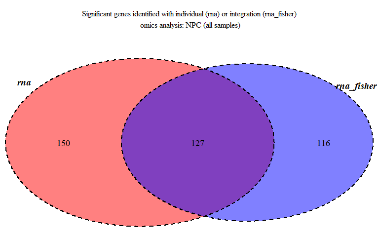

```r
# 12 methylation sites

#Significant genes from mRNA + methylation non parametric combination (Fisher, FDR<0.05)
sig_expr_met_cNPC <- res$qvaluesNPC[which(res$qvaluesNPC[,'Fisher']<0.05),1:2]
# 432 pairs found

#venn diagram
m1 <- list(rna=sig_expr_cNPC, rna_fisher=unique(sig_expr_met_cNPC$expr))

vennPlot1 <- venn.diagram(m1, NULL, fill=c('red','blue'),
                         cat.fontface=4, lty=2, cex=1.2, cat.cex=1.2,
                         main='Significant genes identified with individual (rna) or integration (rna_fisher)\n omics analysis: NPC (all samples)')
grid.newpage()
grid.draw(vennPlot1)
```

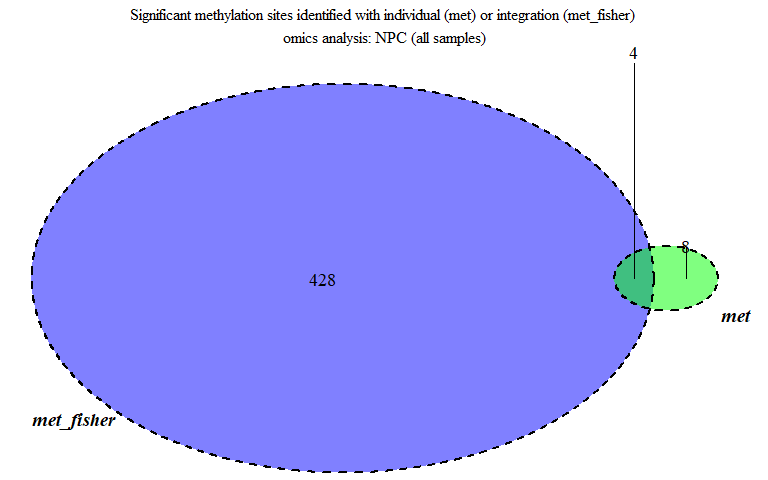

```r
m2 <- list(met=sig_met_cNPC, met_fisher=unique(sig_expr_met_cNPC$met))

vennPlot2 <- venn.diagram(m2, NULL, fill=c('green','blue'),
                         cat.fontface=4, lty=2, cex=1.2, cat.cex=1.2,
                         main='Significant methylation sites identified with individual (met) or integration (met_fisher)\n omics analysis: NPC (all samples)')

grid.newpage()
grid.draw(vennPlot2)
```

For the Non-Parametric approach we get 116 new genes and 428 new methylation sites.

Here we can see part of the list of new genes (n=116) identified based on Fisher combination.

```r
setdiff(sig_expr_met_cNPC$expr,sig_expr_cNPC)[1:50]
```

```
##  [1] "ALDH3A1"  "ALOX5AP"  "AMIGO2"   "AQP1"     "ATP2C2"   "C9orf156"
##  [7] "CCDC88C"  "CCL5"     "CCR1"     "CCR7"     "CD22"     "CD37"
## [13] "CD63"     "CD79B"    "CEACAM21" "CLDN4"    "CMKLR1"   "CNTFR"
## [19] "COCH"     "CRYBA4"   "CRYGB"    "CTLA4"    "CYTL1"    "DENND1C"
## [25] "DENND3"   "DHRS3"    "DLG5"     "EBF2"     "ECEL1"    "EFNA1"
## [31] "ELF3"     "EPHA3"    "EVI2B"    "FCER1G"   "FCHO1"    "FCHSD2"
## [37] "FGD2"     "FGFR2"    "FGL2"     "GABRA5"   "GAST"     "GLUL"
## [43] "GMFG"     "GMIP"     "HCLS1"    "HDAC11"   "HIC1"     "HLA-DMB"
## [49] "HLF"      "HS3ST3A1"
```

And part of the new methylation sites (n=428) identified based on Fisher combination.

```r
setdiff(sig_expr_met_cNPC$met,sig_met_cNPC)[1:50]
```

```
##  [1] "cg24822001" "cg16457786" "cg18957070" "cg24482246" "cg20103124"
##  [6] "cg12199378" "cg12210770" "cg24603490" "cg07473175" "cg19327844"
## [11] "cg15373767" "cg24762359" "cg16634108" "cg06786050" "cg00479411"
## [16] "cg08566293" "cg11635839" "cg19008597" "cg21500300" "cg15742700"
## [21] "cg17124224" "cg00768409" "cg26429925" "cg06523224" "cg20941110"
## [26] "cg27304406" "cg07016258" "cg27169020" "cg26654798" "cg16254374"
## [31] "cg23741520" "cg16049391" "cg14385245" "cg09180848" "cg10275315"
## [36] "cg02713760" "cg14122696" "cg12498409" "cg13486755" "cg01331191"
## [41] "cg03469122" "cg16438210" "cg19411729" "cg07115110" "cg13504059"
## [46] "cg10475172" "cg09824255" "cg05433111" "cg27565966" "cg05981394"
```

#### 2.4.2.4 Integration strategies comparison

Finally, we can compare the divergences between parametric and non-parametric approaches.

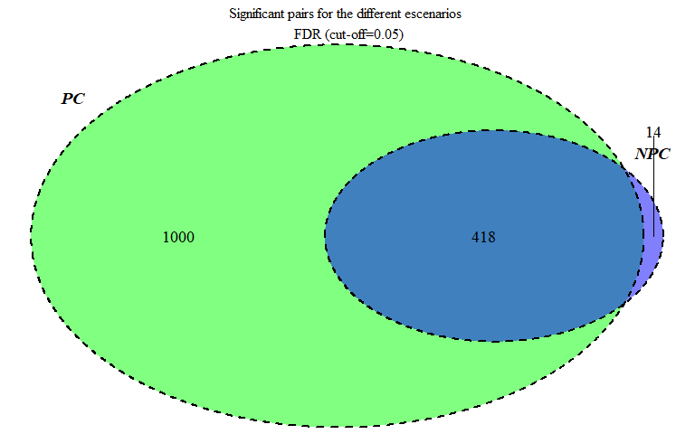

```r
#Significant pairs from different approaches

#parmetric combination significant pairs
PC <- paste(sig_expr_met_cPC$expr,sig_expr_met_cPC$met, sep=":") #3491
#non parmetric combination significant pairs
NPC <- paste(sig_expr_met_cNPC$expr,sig_expr_met_cNPC$met, sep=":") #2885

res_all <- list(PC=PC, NPC=NPC)

vennPlot_m1 <- venn.diagram(res_all, NULL, fill=c("green","blue"),
                            cat.fontface=4, lty=2, cex=1.2, cat.cex=1.2,
                          main="Significant pairs for the different escenarios \n FDR (cut-off=0.05)")

grid.newpage()
grid.draw(vennPlot_m1)
```